# Belief Updating Under Uncertainty

A Simulation Study in R

Author

Elizabeth Cuba Mestre

## 1. Motivation

How should a person update a belief when they receive new evidence?

We rarely approach new information with no expectations. Instead, we begin with assumptions formed from previous experiences and update those beliefs as we encounter new evidence.

This project uses a simplified Bayesian framework to explore how three factors influence belief updating:

1. The strength of an individual’s prior belief
2. The reliability of new evidence
3. The amount of evidence available

The goal is not to model human cognition or clinical disorders directly. Instead, this is a statistical simulation designed to explore how assumptions about prior beliefs and evidence can produce different patterns of belief updating.

## 2. A Simple Bayesian Model

Suppose we are trying to determine whether a hypothesis $H$ is true.

We begin with a prior probability:

$$P(H)$$

We then observe evidence $E$ and update our belief using Bayes’ rule:

$$P(H|E) =
\frac{P(E|H)P(H)}
{P(E|H)P(H) + P(E|\neg H)P(\neg H)}$$

For this simulation, we will interpret the posterior probability as our updated belief after observing evidence.

To make the simulation concrete, suppose an event has a 70% probability if the hypothesis is correct and a 30% probability if the hypothesis is incorrect.

```r
bayes_update <- function(prior, p_e_given_h, p_e_given_not_h) {

  posterior <-
    (p_e_given_h * prior) /
    ((p_e_given_h * prior) +
       (p_e_given_not_h * (1 - prior)))

  return(posterior)
}

bayes_update(
  prior = 0.50,
  p_e_given_h = 0.70,
  p_e_given_not_h = 0.30
)
```

```
[1] 0.7
```

With a neutral 50% prior, observing positive evidence increases the posterior probability of the hypothesis.

## 3. Prior Beliefs and Belief Updating

First, we can examine what happens when two people receive exactly the same evidence but begin with different prior beliefs.

```r
priors <- seq(0.05, 0.95, by = 0.05)

prior_results <- tibble(
  prior = priors,
  posterior = bayes_update(
    prior = priors,
    p_e_given_h = 0.70,
    p_e_given_not_h = 0.30
  )
)

prior_results
```

```
# A tibble: 19 × 2
   prior posterior
   <dbl>     <dbl>
 1  0.05     0.109
 2  0.1      0.206
 3  0.15     0.292
 4  0.2      0.368
 5  0.25     0.438
 6  0.3      0.5
 7  0.35     0.557
 8  0.4      0.609
 9  0.45     0.656
10  0.5      0.7
11  0.55     0.740
12  0.6      0.778
13  0.65     0.812
14  0.7      0.845
15  0.75     0.875
16  0.8      0.903
17  0.85     0.930
18  0.9      0.955
19  0.95     0.978
```

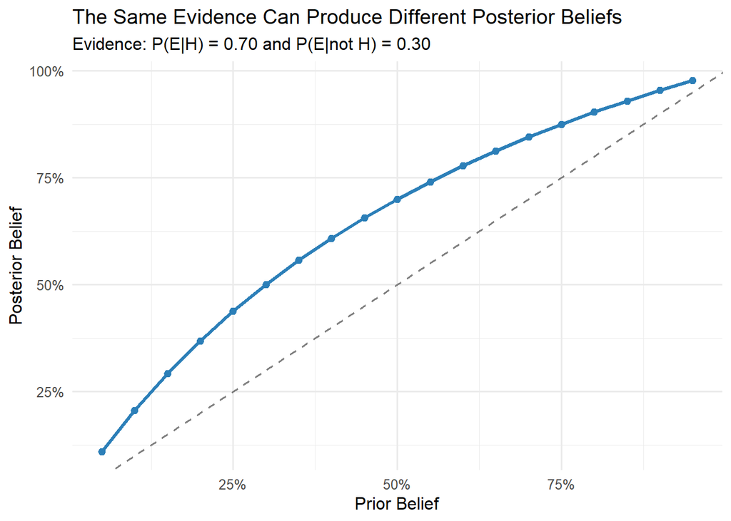

```r
ggplot(prior_results, aes(x = prior, y = posterior)) +
  geom_line(linewidth = 1.1, color = "#2C7FB8") +
  geom_point(size = 2, color = "#2C7FB8") +
  geom_abline(
    slope = 1,
    intercept = 0,
    linetype = "dashed",
    color = "gray50"
  ) +
  scale_x_continuous(labels = scales::percent) +
  scale_y_continuous(labels = scales::percent) +
  labs(
    title = "The Same Evidence Can Produce Different Posterior Beliefs",
    subtitle = "Evidence: P(E|H) = 0.70 and P(E|not H) = 0.30",
    x = "Prior Belief",
    y = "Posterior Belief"
  )
```

The simulation illustrates an important property of Bayesian updating where the same evidence does not necessarily lead to the same posterior belief when starting beliefs differ.

This does not mean that prior beliefs are always “correct” or “incorrect.” Rather, the mathematical framework makes explicit how previous information enters the updating process.

## 4. Evidence Reliability

The amount of updating should also depend on how informative the evidence is.

- Weak evidence
- Moderate evidence
- Strong evidence

```r
evidence_conditions <- tribble(
  ~condition, ~p_e_given_h, ~p_e_given_not_h,
  "Weak",      0.55,          0.45,
  "Moderate",  0.70,          0.30,
  "Strong",    0.90,          0.10
)

evidence_results <- crossing(
  prior = priors,
  evidence_conditions
) %>%
  mutate(
    posterior = bayes_update(
      prior,
      p_e_given_h,
      p_e_given_not_h
    ),
    absolute_update = abs(posterior - prior)
  )

evidence_results
```

```
# A tibble: 57 × 6
   prior condition p_e_given_h p_e_given_not_h posterior absolute_update
   <dbl> <chr>           <dbl>           <dbl>     <dbl>           <dbl>
 1  0.05 Moderate         0.7             0.3     0.109           0.0594
 2  0.05 Strong           0.9             0.1     0.321           0.271
 3  0.05 Weak             0.55            0.45    0.0604          0.0104
 4  0.1  Moderate         0.7             0.3     0.206           0.106
 5  0.1  Strong           0.9             0.1     0.5             0.4
 6  0.1  Weak             0.55            0.45    0.120           0.0196
 7  0.15 Moderate         0.7             0.3     0.292           0.142
 8  0.15 Strong           0.9             0.1     0.614           0.464
 9  0.15 Weak             0.55            0.45    0.177           0.0274
10  0.2  Moderate         0.7             0.3     0.368           0.168
# ℹ 47 more rows
```

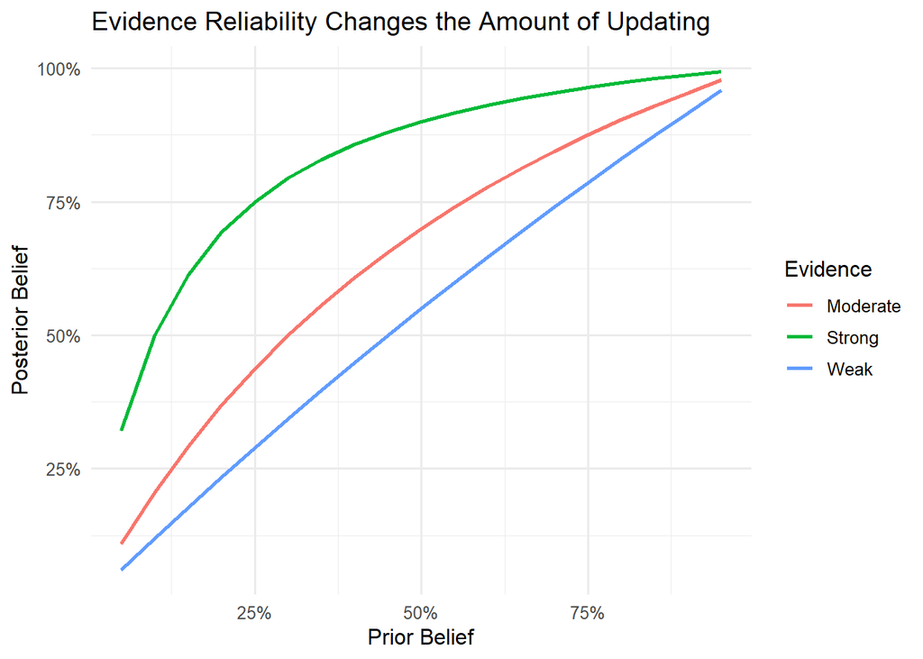

```r
ggplot(
  evidence_results,
  aes(
    x = prior,
    y = posterior,
    color = condition
  )
) +
  geom_line(linewidth = 1) +
  scale_x_continuous(labels = scales::percent) +
  scale_y_continuous(labels = scales::percent) +
  labs(
    title = "Evidence Reliability Changes the Amount of Updating",
    x = "Prior Belief",
    y = "Posterior Belief",
    color = "Evidence"
  )
```

The model predicts that stronger evidence produces larger changes in belief, particularly when the prior belief is not already close to the evidence-supported conclusion.

## 5. Simulating Repeated Evidence

A single piece of evidence is not the only way beliefs can change.

Suppose evidence is observed repeatedly. We can simulate repeated observations and update the posterior after every observation.

```r
simulate_updates <- function(
    prior,
    p_e_given_h,
    p_e_given_not_h,
    n_observations = 50
) {

  observations <- rbinom(
    n_observations,
    size = 1,
    prob = p_e_given_h
  )

  posterior <- numeric(n_observations)

  current_prior <- prior

  for (i in seq_len(n_observations)) {

    if (observations[i] == 1) {

      current_prior <- bayes_update(
        current_prior,
        p_e_given_h,
        p_e_given_not_h
      )

    } else {

      current_prior <- bayes_update(
        current_prior,
        1 - p_e_given_h,
        1 - p_e_given_not_h
      )
    }

    posterior[i] <- current_prior
  }

  tibble(
    observation = seq_len(n_observations),
    evidence = observations,
    posterior = posterior
  )
}

simulation <- simulate_updates(
  prior = 0.20,
  p_e_given_h = 0.70,
  p_e_given_not_h = 0.30,
  n_observations = 50
)

head(simulation)
```

```
# A tibble: 6 × 3
  observation evidence posterior
        <int>    <int>     <dbl>
1           1        1     0.368
2           2        1     0.576
3           3        1     0.761
4           4        0     0.576
5           5        0     0.368
6           6        1     0.576
```

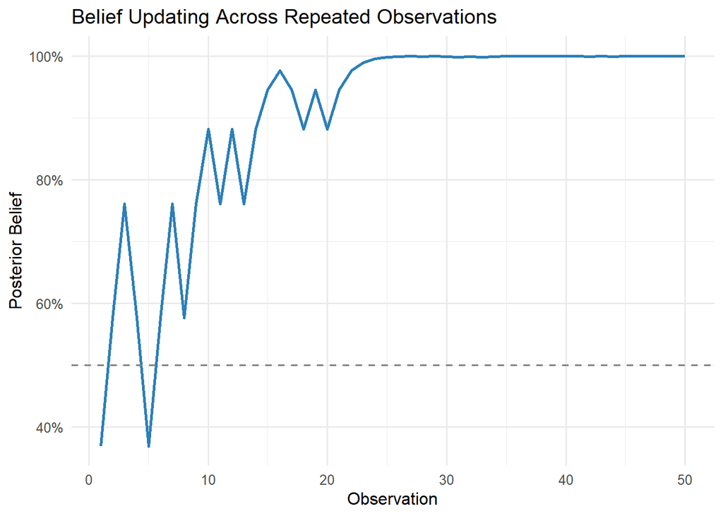

```r
ggplot(
  simulation,
  aes(x = observation, y = posterior)
) +
  geom_line(
    linewidth = 1,
    color = "#2C7FB8"
  ) +
  geom_hline(
    yintercept = 0.5,
    linetype = "dashed",
    color = "gray50"
  ) +
  scale_y_continuous(labels = scales::percent) +
  labs(
    title = "Belief Updating Across Repeated Observations",
    x = "Observation",
    y = "Posterior Belief"
  )
```

Because the evidence is probabilistic, individual simulations can produce different paths.

## 6. A Simulated Behavioral Dataset

The previous sections treated prior belief and evidence reliability as mathematical parameters.

We can also create a simulated dataset representing individual participants.

Each simulated participant will receive a different prior belief and different evidence reliability. We will then measure the amount of belief updating.

```r
set.seed(2200)

n_participants <- 500

participants <- tibble(
  participant = 1:n_participants,
  prior_strength = runif(
    n_participants,
    min = 0.05,
    max = 0.95
  ),
  evidence_reliability = runif(
    n_participants,
    min = 0.50,
    max = 0.95
  )
) %>%
  mutate(
    p_e_given_h = evidence_reliability,
    p_e_given_not_h = 1 - evidence_reliability,
    posterior = bayes_update(
      prior_strength,
      p_e_given_h,
      p_e_given_not_h
    ),
    belief_update = posterior - prior_strength,
    absolute_update = abs(belief_update)
  )

head(participants)
```

```
# A tibble: 6 × 8
  participant prior_strength evidence_reliability p_e_given_h p_e_given_not_h
        <int>          <dbl>                <dbl>       <dbl>           <dbl>
1           1          0.652                0.570       0.570           0.430
2           2          0.369                0.626       0.626           0.374
3           3          0.395                0.696       0.696           0.304
4           4          0.877                0.625       0.625           0.375
5           5          0.708                0.803       0.803           0.197
6           6          0.620                0.640       0.640           0.360
# ℹ 3 more variables: posterior <dbl>, belief_update <dbl>,
#   absolute_update <dbl>
```

## 8. Visualizing Simulated Participants

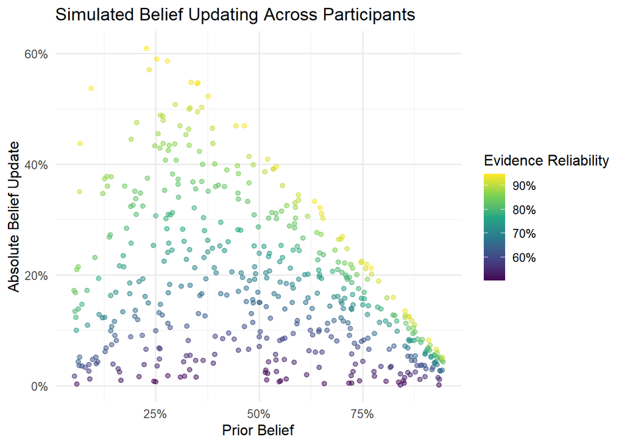

```r
ggplot(
  participants,
  aes(
    x = prior_strength,
    y = absolute_update,
    color = evidence_reliability
  )
) +
  geom_point(alpha = 0.5) +
  scale_x_continuous(labels = scales::percent) +
  scale_y_continuous(labels = scales::percent) +
  scale_color_viridis_c(
    labels = scales::percent
  ) +
  labs(
    title = "Simulated Belief Updating Across Participants",
    x = "Prior Belief",
    y = "Absolute Belief Update",
    color = "Evidence Reliability"
  )
```

The visualization suggests that belief updating depends jointly on starting beliefs and the strength of the evidence.

## 9. Regression Analysis

```r
model <- lm(
  absolute_update ~ prior_strength + evidence_reliability,
  data = participants
)

summary(model)
```

```
Call:
lm(formula = absolute_update ~ prior_strength + evidence_reliability,
    data = participants)

Residuals:
     Min       1Q   Median       3Q      Max
-0.21259 -0.03776  0.01901  0.03880  0.18932

Coefficients:
                     Estimate Std. Error t value Pr(>|t|)
(Intercept)          -0.34138    0.01982  -17.22   <2e-16 ***
prior_strength       -0.18466    0.01226  -15.06   <2e-16 ***
evidence_reliability  0.84972    0.02527   33.62   <2e-16 ***
---
Signif. codes:  0 '***' 0.001 '**' 0.01 '*' 0.05 '.' 0.1 ' ' 1

Residual standard error: 0.07031 on 497 degrees of freedom
Multiple R-squared:  0.7362,    Adjusted R-squared:  0.7351
F-statistic: 693.4 on 2 and 497 DF,  p-value: < 2.2e-16
```

The regression provides a simple way to examine whether prior strength and evidence reliability are associated with the magnitude of simulated belief updating.

```r
broom::tidy(model)
```

```
# A tibble: 3 × 5
  term                 estimate std.error statistic   p.value
  <chr>                   <dbl>     <dbl>     <dbl>     <dbl>
1 (Intercept)            -0.341    0.0198     -17.2 1.85e- 52
2 prior_strength         -0.185    0.0123     -15.1 1.69e- 42
3 evidence_reliability    0.850    0.0253      33.6 4.26e-130
```

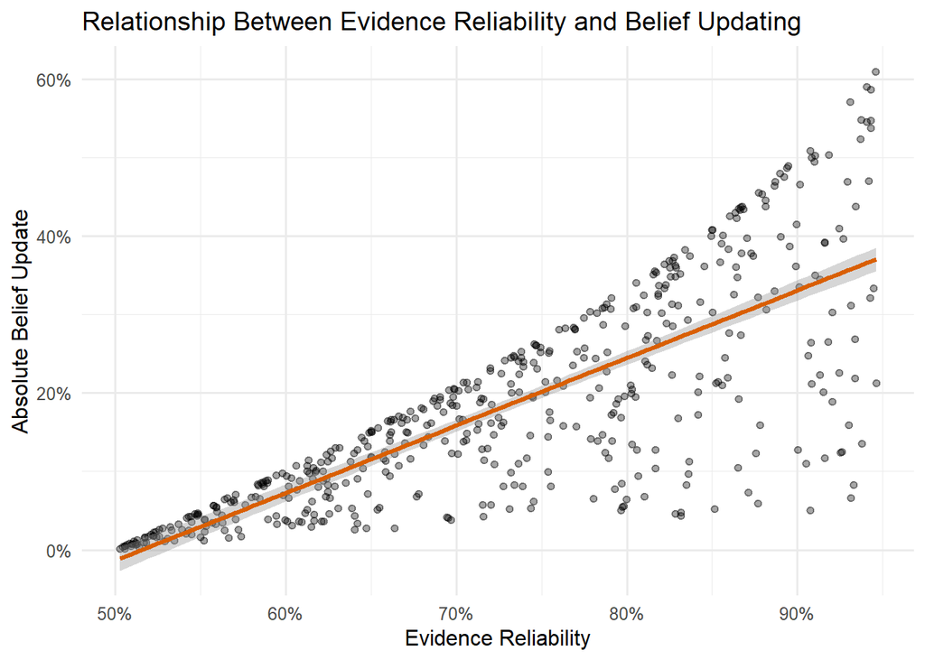

```r
ggplot(
  participants,
  aes(
    x = evidence_reliability,
    y = absolute_update
  )
) +
  geom_point(alpha = 0.35) +
  geom_smooth(
    method = "lm",
    se = TRUE,
    color = "#D95F02"
  ) +
  scale_x_continuous(labels = scales::percent) +
  scale_y_continuous(labels = scales::percent) +
  labs(
    title = "Relationship Between Evidence Reliability and Belief Updating",
    x = "Evidence Reliability",
    y = "Absolute Belief Update"
  )
```

## 10. Bootstrap Confidence Interval

```r
set.seed(2200)

bootstrap_means <- map_dbl(
  seq_len(5000),
  function(i) {

    sample_data <- participants %>%
      slice_sample(
        n = nrow(participants),
        replace = TRUE
      )

    mean(sample_data$absolute_update)
  }
)

bootstrap_ci <- quantile(
  bootstrap_means,
  probs = c(0.025, 0.975)
)

bootstrap_ci
```

```
     2.5%     97.5%
0.1696918 0.1933017
```

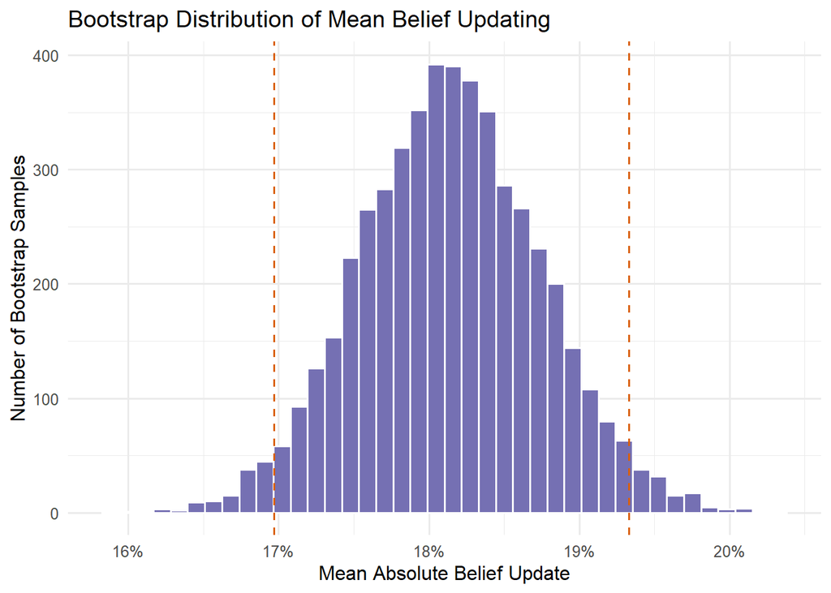

```r
ggplot(
  tibble(mean_update = bootstrap_means),
  aes(x = mean_update)
) +
  geom_histogram(
    bins = 40,
    fill = "#7570B3",
    color = "white"
  ) +
  geom_vline(
    xintercept = bootstrap_ci,
    color = "#D95F02",
    linetype = "dashed"
  ) +
  scale_x_continuous(labels = scales::percent) +
  labs(
    title = "Bootstrap Distribution of Mean Belief Updating",
    x = "Mean Absolute Belief Update",
    y = "Number of Bootstrap Samples"
  )
```

The bootstrap distribution provides a representation of the uncertainty surrounding the estimated mean absolute belief update.

## 11. Interpreting the Results

The simulation demonstrates several general patterns.

First, prior beliefs influence posterior beliefs. When the same evidence is presented to individuals with different starting beliefs, the resulting posterior beliefs can differ.

Furthermore, evidence reliability affects the amount of updating. More informative evidence generally produces larger changes in belief.

Thus, the simulated participant analysis demonstrates how statistical tools such as regression and bootstrap resampling can be used to quantify relationships and uncertainty in simulated behavioral data.

## 12. What I Learned

This simulation reinforced several concepts from probability and statistics:

- Prior assumptions can influence how new evidence changes a posterior belief.
- The informativeness of evidence affects the magnitude of updating.
- Repeated stochastic observations can produce different individual trajectories.
- Regression can quantify relationships between simulated behavioral variables.
- Bootstrap methods can estimate uncertainty without relying entirely on parametric assumptions.

## 13. Limitations and Future Directions

This project intentionally uses a highly simplified Bayesian framework.

Thus it does not model individual differences in cognition or any actual patient behavior

A natural next step would be to introduce more realistic simulated behavioral data and compare alternative computational models of belief updating.

## 14. Conclusion

This project began as an exploration of probability and Bayesian updating but became a useful way for me to think about how mathematical models can represent aspects of human belief formation.

The most interesting part was not obtaining a single answer, but seeing how different assumptions about prior beliefs and evidence can produce different outcomes.